# Columbia R. Sp. Ck. Forecast

Last Updated 12/12/2022.

# Setup

All analyses require R software [**(link)**](https://cran.r-project.org/) (v3.4.3) for data retrieval, data processing, and summarizing model results. Here we configure R to perform our analysis and generate our outputs

```r
options(width = 100)
knitr::opts_chunk$set(message = FALSE)
set.seed(123)
```

```r
wd_functions<-"../functions"
sapply(FUN = source, paste(wd_functions, list.files(wd_functions), sep="/"))
```

Here we will load & install packages we need to use (needs internet connection if packages not already installed)

```r
packages_list<-c("tidyverse"
                 ,"forecast"
                 ,"mgcv"
                 ,"ggplot2"
                 ,"MASS"
                 ,"RColorBrewer"
                 ,"kableExtra"
                 ,"gtools"
                 # ,"ggfortify"
                 ,"lubridate"
                 ,"brms"
                 ,"bsplus"
                 ,"here"
                 # ,"rnoaa"
                 # ,"ncdf4"
                 # ,"ncdf4.helpers"
                 # ,"raster"
                 # ,"reshape2"
                 # ,"ggfortify"
                 )
install_or_load_pack(pack = packages_list)
```

# Load Data

Here we will load and format our data for analysis. First, we will load and format our fish data for analysis. What you load is what you will forecast (so you can forecast run size or escapement)

```r
#====================================
#get columbia spring chinook data as example
#====================================
# dat<-read_csv("http://www.cbr.washington.edu/dart/cs/php/rpt/adult_annual.php?sc=1&outputFormat=csv&proj=BON&startdate=1%2F1&enddate=6%2F15")%>%
#   arrange(Year)%>%
#   dplyr::select(Year, Chinook, `Jack Chinook`)%>%
#   dplyr::rename(runsize_obs=Chinook)%>%
#   mutate(`runsize_obs`=ifelse(as.numeric(Year)<=as.numeric(format(Sys.Date(),"%Y")),`runsize_obs`,NA))%>%
#   mutate(`Jack Chinook` = ifelse(`Jack Chinook`==0,NA,`Jack Chinook`))%>%
#   filter(!is.na(Year),
#          between(Year,1990,2023))


# dat<-readxl::read_xlsx(here("Data","CKL_2019.xlsx")) %>%
 dat<-read_csv(here("Data","UpriverSpring_Return.csv")) %>%
         rename(`Jack Chinook`=Age3,
                Year=ReturnYear,
                runsize_obs=Return )
# dat

thisYr<-as.numeric(format(Sys.Date(),"%Y"))+1
dat<-dat%>%filter(Year<thisYr)

Yrlist<-data.frame(Year=c((min(dat$Year)-2):(max(dat$Year)+1)))
dat<-left_join(Yrlist,dat)

#look at our data
print(tail(data.frame(dat)))
```

```
##    Year                  Stock Jack.Chinook   Age4  Age5 Age6 runsize_obs
## 37 2018 Upriver_spring_Chinook         7563 104702 10111  268      115081
## 38 2019 Upriver_spring_Chinook         9092  59860 13072  173       73105
## 39 2020 Upriver_spring_Chinook         7953  74294  6927   80       81301
## 40 2021 Upriver_spring_Chinook        15592  76871 14717  148       91736
## 41 2022 Upriver_spring_Chinook        23957 170275 14594  340      185209
## 42 2023                   <NA>           NA     NA    NA   NA          NA
```

The section will (optionally) download from the web (or load from the data folder) NOAA Ocean Indicator data, NOAA Ocean Buoy SST data, and NOAA smoothed modeled SST data (ERSST_V5), flow data, PIT tag data, or any other covariate data not included with the fish data that could assist in forecasting.

```r
#=========================================================
#get PIT tag survival/age data
#=========================================================
# PIT<-read_csv("data/Columbia_Steelhead_SAR_DART_11_1_2021.csv")%>%
#   dplyr::rename(OutmigrationYear=year)%>%
#   mutate(Year=OutmigrationYear+1)%>%
#   filter(Pop=="SNA")
#
# SAR1<-data.frame(SAR1=gam(cbind(ocean1Count,juvCount-ocean1Count)~s(OutmigrationYear,k=(dim(PIT)[1])),family=binomial,data=PIT)$fitted)
#
# PIT<-PIT%>%
#   bind_cols(SAR1)
#=========================================================
#get PDO data
#=========================================================
PDO<-read_table("https://psl.noaa.gov/pdo/data/pdo.timeseries.ersstv5.csv",skip=1,col_names=F,comment="#")%>%
  dplyr::rename(Date=X1,PDO=X2)%>%
  filter(!PDO < -99)%>%
  mutate(Date=as.Date(Date),Month=month(Date),Year=year(Date))%>%
  group_by(Year)%>%
  add_tally()%>%
  #filter(!Month>6)%>% #use only spring (Jan-June) NPGO
  #filter(!n < 12)%>% #use only complete years
  group_by(Year)%>%
  dplyr::summarise(PDO=mean(PDO))
#=========================================================
#get NPGO data
#=========================================================
NPGO<-read_table("http://www.o3d.org/npgo/npgo.php",skip=29,col_names=F,comment="#")%>%
  filter(!is.na(X2))%>%
  dplyr::rename(Year=X1,Month=X2,NPGO=X3)%>%
  mutate(Year=as.numeric(Year))%>%
  group_by(Year)%>%
  add_tally()%>%
  #filter(!Month>6)%>% #use only spring (Jan-June) NPGO
  #filter(!n < 12)%>% #use only complete years
  group_by(Year)%>%
  dplyr::summarise(NPGO=mean(NPGO))
#=========================================================
#get NOAA indicator data, wrangle into usable format, plot
#=========================================================
indicators<-read_csv("https://media.fisheries.noaa.gov/2022-03/Stoplight-updated-03282022_0.csv",skip=1)%>%
# indicators<-read_csv("data/Stoplight csv.csv",skip=1)%>%
  filter(!is.na(`Ecosystem Indicators`))%>%
  pivot_longer(names_to = "Year",
                cols=c(starts_with("1"),starts_with("2")),
                values_to = "value")%>%
  pivot_wider(names_from=`Ecosystem Indicators`,values_from=value)%>%
  mutate(Year=as.numeric(Year))

# plotdat<-indicators%>%pivot_longer(names_to = "indicators", cols = colnames(indicators)[colnames(indicators)!="Year"])
# ggplot(plotdat,aes(x=value,color=indicators))+
#   geom_density()+
#   facet_wrap(~indicators,scales="free")+
#   theme(legend.position = "none")

#==============================================================
# get NOAA sst data directly from Buoys (takes a while to run)
#==============================================================
# buoylist<-c(46229, 46211, 46041, 46029, 46050, 46097, 46098)
# years<-c(1980:2021)
# buoy_stations()%>%filter(lat > 44 & lat < 52 & lon > -130 & lon < -120)
# buoydat<-getbuoydata(buoylist = buoylist,years=years)
# write.csv(dat,"SST.csv",row.names = F)

#===================
#Plot Buoy SST data
#====================
# buoydat<-buoydat%>%
#   filter(!is.na(buoyid) & !is.na(meanSST))%>%
#   group_by(buoyid,month)%>%
#   mutate(gmeanSST=mean(meanSST),resid=meanSST-gmeanSST)
#
#
# ggplot(buoydat,aes(x=month,y=resid,group=factor(buoyid),color=factor(buoyid)))+
#   geom_hline(yintercept=0,linetype="dashed")+
#   scale_color_brewer(palette = "Spectral")+
#   geom_line()+
# facet_wrap(~factor(year))


#===========================================================================================================
#Get ERSST data: get_ersst_v5_data takes A LONG TIME (1 hr) vs. get_ersst_v5_data_V2 which is much quicker!
#===========================================================================================================
#dat<-get_ersst_v5_data(years=years,data.dir=getwd(),latrange=c(44,52),lonrange=c(-130,-120))
# sstdat<-get_ersst_v5_data_V2(years=c(1980:2021),
#                              data.dir="C:/Users/buehrtwb/OneDrive - Washington State Executive Branch Agencies/Documents" ,
#                              ncfilename="SSTv5.nc",
#                              latrange=c(44,50),
#                              lonrange=c(-125,-120)
#                              )

# sstdat<-sstdat%>%
#   mutate(sstdiff=c(NA,diff(resid)))
#
# #================
# #Plot ERSST data
# #================
# ggplot(sstdat,aes(x=factor(month),y=meanSST,group=year))+
#   geom_hline(yintercept=0,linetype="dashed")+
#   scale_color_brewer(palette = "Spectral")+
#   geom_line()+
#   facet_wrap(~factor(year))
#
# ggplot(sstdat,aes(x=factor(month),y=resid,group=year))+
#   geom_hline(yintercept=0,linetype="dashed")+
#   scale_color_brewer(palette = "Spectral")+
#   geom_line()+
#   facet_wrap(~factor(year))
#
# ggplot(sstdat,aes(x=factor(month),y=sstdiff,group=year))+
#   geom_hline(yintercept=0,linetype="dashed")+
#   scale_color_brewer(palette = "Spectral")+
#   geom_line()+
#   facet_wrap(~factor(year))
#
# ssta<-sstdat%>%
#   dplyr::select(year,month,resid)%>%
#   mutate(month = paste0("m_",month))%>%
#   rename(Year = year)%>%
#   pivot_wider(names_from = month,values_from = resid)
#
# pcdat<-ssta%>%
#   ungroup()%>%
#   filter(Year<2021)%>%
#   column_to_rownames(var="Year")
# mod<-prcomp(pcdat
#             )
# autoplot(mod,data=ssta%>%filter(Year<2021)%>%column_to_rownames(var="Year"),
#          x=1,
#          y=3,
#          label = TRUE,
#          label.size = 3,
#          shape=F)
```

If we loaded/downloaded covariate data (other than fish abundance) for use in forecasting, in this section we will merge it with our fish data to produce a final dataframe. Note the format below; the rest of the functions and sections rely on your data being formatted this way,

```r
dat2<-dat%>%
  #left_join(PIT)%>%
  left_join(PDO)%>%
  left_join(NPGO)%>%
  left_join(indicators)%>%
  ungroup %>%

  #left_join(ssta)%>%
  mutate(
    # l1aprssta= lag(scale(m_04)),
    # l1mayssta= lag(scale(m_05)),
    # l1junssta= lag(scale(m_06)),
    # l1julssta= lag(scale(m_07)),
    # l1augssta= lag(scale(m_08)),
    # l1sepssta= lag(scale(m_09)),
    # l1octssta= lag(scale(m_10)),
    # l1novssta= lag(scale(m_11)),
    # l1decssta= lag(scale(m_12)),
    # l1FallSST= (lag(scale(m_10)) + lag(scale(m_11)) + lag(scale(m_12)))/3,
    # PC1 = lag(mod$x[,1]),
    # PC2 = lag(mod$x[,2]),
    # PC3 = lag(mod$x[,3]),
    # lag1_summerPDO = lag(scale(`PDO\n(Sum May-Sept)`)),
    # lag1_springONI = lag(scale(`ONI\n(Average Jan-June)`)),
    # lag1_summerdeepSST = lag(scale(`Deep temperature\n(°C; May-Sept)`)),
    # lag1_summerdeepSalinity = lag(scale(`Deep salinity\n(May-Sept)`)),
    # lag1_copepodrich = lag(scale(`Deep salinity\n(May-Sept)`)),
    # lag1_icthy = lag(scale(`Nearshore Ichthyoplankton\nLog(mg C 1,000 m-3; Jan-Mar)`)),
    # lag1_cpueCO = lag(scale(log(`Chinook salmon juvenile\ncatches (no. km-1; June)`))),
    # lag1_phystrans = lag (scale(`Physical Spring Trans.\nUI based (day of year)`)),
    # lag1_Ncope = lag(scale(`N. copepod biomass anom.\n(mg C m-3; May-Sept)`)),
    # lag1_summerSST=lag(scale(`Upper 20 m T\n(°C; May-Sept)`)),
    lag1_JCK = lag(c(scale(log(`Jack Chinook`)))),
    # lag1_PC1 = lag(scale(`Principal Component scores (PC1)`)),
    # lag1_PC2 = lag(scale(`Principal Component scores (PC2)`)),
    lag2_PC1 = lag(scale(`Principal Component scores (PC1)`),2),
    lag2_PC2 = lag(scale(`Principal Component scores (PC2)`),2),
    lag1_NPGO = lag(c(scale(NPGO))),
    lag2_NPGO = lag(c(scale(NPGO)),2),
    lag1_PDO = lag(c(scale(PDO))),
    lag2_PDO = lag(c(scale(PDO)),2)
    )

#select variables to include in analysis and subset data
vars2<-c("lag1_JCK"
        # ,"lag1_PC1"
        ,"lag2_PC1"
        # ,"lag1_PC2"
        ,"lag2_PC2"
        ,"lag1_NPGO"
        ,"lag2_NPGO"
        ,"lag1_PDO"
        ,"lag2_PDO"
        )
dat3<-data.frame(dat2)%>%
  dplyr::select(Year,runsize_obs,all_of(vars2))%>%
  filter(
    across(
      .cols = all_of(vars2),
      .fns = ~ !is.na(.x)
    )
  )#%>%filter(Year>1999)
#look at our data
# print(data.frame(dat))
```

# Set Parameters

Here we specify parameters for our forecast training and evaluation: how many years of training data to include in the training set (validation is the rest), how many years forward to forecast (typically 1), and make some selections regarding which metric to use to evaluate forecast model performance.

```r
#set model fitting and evaluation params
TY <- dim(dat)[1]-14 #training years (years of training data)
FY <- 1 #forecast years (years foreward to forecast)
k = 1 #this is the model-averaging weighting exponent--default is 1, larger numbers will tend to more heavily weight "best" models over lower ranked models
stack_metric = "MAPE" #this is the performance measure that will be optimized to find the best stack weights
```

# Fit Forecast Models

Here we fit ARIMA and GAM forecasts

```r
dat<-dat3
best_covariates<-all_subsets(series=dat3,covariates=vars2,min=0,max=4)

# print(
# best_covariates[[2]] %>%
#   slice(1:10)%>%
#   kbl(caption = "Table 1. Covariate Model Selection Results.",digits =3)%>%
#   kable_classic(full_width = F, html_font = "Cambria")
# )
# best_covariates[[1]][best_covariates[[2]]$model_num[1:10]]


results<-inseason_forecast_v2(dat,
                  leave_yrs=15,
                  covariates=best_covariates[[1]][best_covariates[[2]]$model_num[1:10]],
                  # first_forecast_period = first_forecast_period,
                  # plot_results = plot_results,
                  write_model_summaries = T,
                  # forecast_period_start_m =  forecast_period_start_m, #inclusive
                  # forecast_period_start_d =  forecast_period_start_d, #inclusive

                  # p1_covariates_only=NULL,
                  seasonal=FALSE,
                  stack_metric = "MAPE"
                  )

model_list<-lapply(best_covariates[[1]][best_covariates[[2]]$model_num[1:10]],function(x) paste(x,collapse = " + "))%>%
  unlist()%>%
  as_tibble()%>%
  add_rownames()%>%
  dplyr::rename(model=rowname,model_name=value)
```

```r
results$forecasts%>%
  filter(Year==max(Year))%>%
  left_join(model_list %>% rename(Model=model))%>%
  left_join(results$final_model_weights%>% rename(Model=model))%>%
    dplyr::select(-c(MAPE,RMSE,MSA)) %>%
  left_join(results$forecast_skill) %>%
  mutate(model_name = ifelse(is.na(Stacking_weight),Model,model_name))%>%
  dplyr::select(Year,model_name,predicted_runsize_obs,MAPE,RMSE,MSA,`Lo 50`,`Hi 50`,`Lo 95`,`Hi 95`,Stacking_weight)%>%
  arrange(MAPE) %>%
  kbl(caption = "Table: Forecasts and permance metrics",digits =2)%>%
  kable_classic(full_width = F, html_font = "Cambria")
```

Table: Forecasts and permance metrics

| Year | model_name | predicted_runsize_obs | MAPE | RMSE | MSA | Lo 50 | Hi 50 | Lo 95 | Hi 95 | Stacking_weight |
| --- | --- | --- | --- | --- | --- | --- | --- | --- | --- | --- |
| 2023 | lag1_JCK + lag2_PC2 + lag1_PDO + lag2_PDO | 175312.5 | 22.26 | 33004.03 | 23.85 | 152637.90 | 201355.4 | 117226.27 | 262180.6 | 0.13 |
| 2023 | lag1_JCK + lag2_PC2 + lag2_PDO | 187199.0 | 24.45 | 46854.33 | 25.82 | 158938.61 | 220484.3 | 116351.75 | 301185.6 | 0.45 |
| 2023 | lag1_JCK + lag1_PDO + lag2_PDO | 240612.4 | 25.30 | 40607.40 | 28.28 | 202755.23 | 285538.0 | 146312.07 | 395690.6 | 0.00 |
| 2023 | MAPE_weighted | 203791.2 | 25.59 | 47200.92 | 25.29 | NA | NA | 124512.32 | 334006.3 | NA |
| 2023 | RMSE_weighted | 205264.8 | 25.61 | 47387.56 | 25.38 | NA | NA | 125315.58 | 336679.3 | NA |
| 2023 | lag1_JCK + lag2_PC2 + lag1_NPGO + lag1_PDO | 107380.9 | 25.70 | 50333.13 | 26.38 | 91431.43 | 126112.8 | 67298.73 | 171335.6 | 0.43 |
| 2023 | MSA_weighted | 203692.7 | 26.00 | 47625.11 | 25.79 | NA | NA | 124478.11 | 333774.2 | NA |
| 2023 | Stack_weighted | 151701.7 | 26.20 | 50105.73 | 24.99 | NA | NA | 95583.65 | 240920.0 | NA |
| 2023 | lag1_JCK + lag2_PDO | 247331.2 | 32.13 | 56476.55 | 35.59 | 205687.32 | 297406.5 | 144745.01 | 422624.2 | 0.00 |
| 2023 | lag1_JCK + lag2_PC1 + lag2_PC2 + lag2_PDO | 197043.8 | 33.22 | 61118.28 | 34.03 | 167153.32 | 232279.3 | 122164.91 | 317818.4 | 0.00 |
| 2023 | lag1_JCK + lag2_PC1 + lag2_PC2 + lag1_PDO | 188977.3 | 35.09 | 57273.23 | 37.57 | 159413.25 | 224024.1 | 115268.47 | 309819.5 | 0.00 |
| 2023 | lag1_JCK + lag2_PC1 + lag2_PC2 | 202392.6 | 35.46 | 60638.84 | 37.78 | 170327.79 | 240493.8 | 122608.33 | 334094.6 | 0.00 |
| 2023 | lag1_JCK + lag2_PC1 | 254094.0 | 35.78 | 64002.68 | 37.64 | 211880.18 | 304718.2 | 149868.84 | 430801.7 | 0.00 |
| 2023 | lag1_JCK + lag2_PC1 + lag2_PDO | 257131.1 | 37.12 | 67520.11 | 38.90 | 214771.98 | 307844.7 | 152399.72 | 433835.6 | 0.00 |

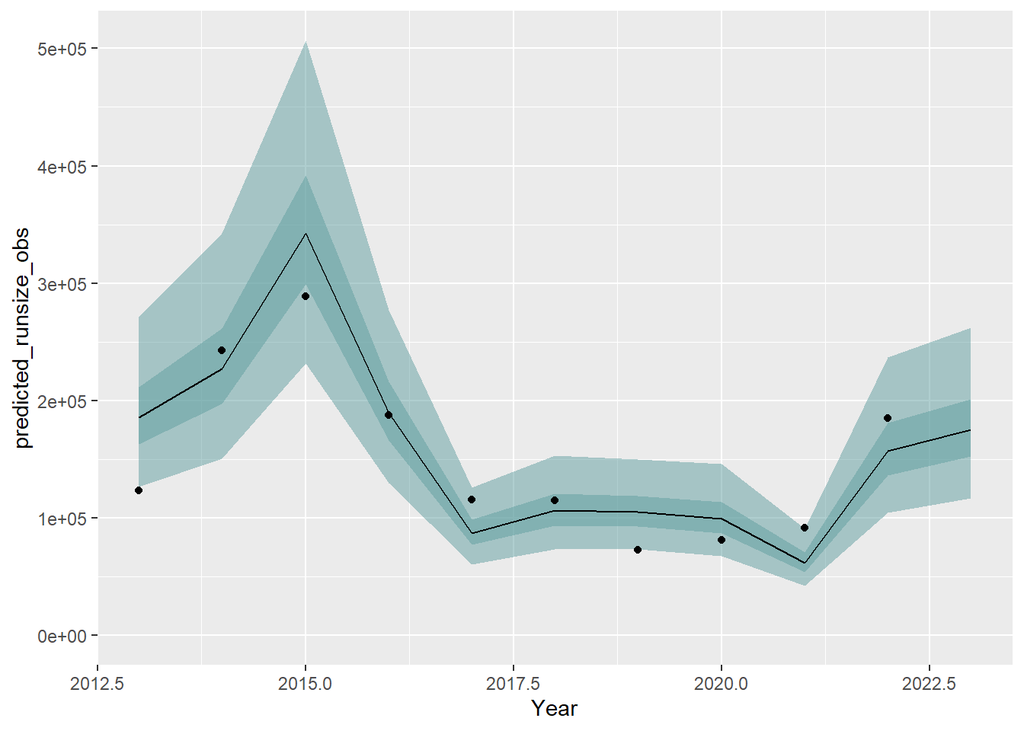

```r
# if(length(unique(results$model))>1){

  results_best<-results$forecasts%>%
  ungroup()%>%
  filter(Model ==(results$final_model_weights %>% arrange(MAPE) %>% pull(model))[1])
# }



# results_best%>%
#   dplyr::select(!c("train_test"))%>%
#   kbl(caption = paste0("Table 2. Forecasts of ","Bonneville dam counts of spring Chinook"),digits =2)%>%
#   kable_classic(full_width = F, html_font = "Cambria")

# print(paste0("Mean Absolute Percent Error (MAPE) = ",mean(abs((results_best$error/results$runsize_obs)*100),na.rm = T)))
# print(paste0("Median Symmetric Accuracy; MSA) = ",100*(exp(median(abs(log(results_best$predicted_runsize_obs/results$runsize_obs)),na.rm = T))-1)))

p<-ggplot(results_best,aes(x=Year,y=predicted_runsize_obs))+
  geom_ribbon(aes(ymin=`Lo 95`,ymax=`Hi 95`),color=NA,alpha=0.5,fill = "cadetblue")+
  geom_ribbon(aes(ymin=`Lo 50`,ymax=`Hi 50`),color=NA,alpha=0.5,fill = "cadetblue")+
  geom_line()+
  geom_point(aes(x=Year,y=runsize_obs))+
  ylim(0,NA)#+
  # scale_x_continuous(breaks=unique(results$Year))

print(p)
```